# Data Managment: Objects and Files

Thomas Manke

31 May 2016

# Saving objects as Rdat files

In the process of data exploration we often generate many new data objects. Just as with figures, we may also save data objects for later use.

The following call saves an “image” of all data obejcts in a compressed file format (conventional: *.Rdat)

```r
save.image(file="04.Rdat")
```

**Task**: What happens if the “file=” parameter is omitted? Saving all data can be an overkill. Find out how to save only selected or single objects, e.g. S.

# Saving objects as text files

Rdat files are most convenient for future processing with R. Sometimes we need to save objects in (tab-separated) text files:

```r
write.table(iris, file="iris.tsv", sep="\t", row.names=FALSE, quote=FALSE)
```

# Tracking objects

In RStudio, explore the “Environment” tab. On the console there are also many convenient commands to track (and delte) objects from memory.

```r
ls()     # list all obejct
rm(x)    # remove object x
# rm(list=ls()) # Careful: This removes all objects
```

# Navigation: Where am I, where are my files?

In Rstudio, explore the “Files” tab. On the console:

```r
getwd()         # get the full path of the current working directory
list.files()    # list all files in working directory
setwd("~")      # change working directory to new directory (here: "~" = home)
list.files(pattern=".Rdat") # list all ".Rdat files in working directory
```

# The theory of I/O

Reading external data into R is easy, but it is crucial to have a very clean and well-defined data structure.

```r
# load("04.Rdat")  # easiest and fastest for previously generated Rdat files
iris_f=read.table(file="../data/iris.tsv", sep="\t", header=TRUE)
str(iris_f)
```

```
## 'data.frame':    150 obs. of  5 variables:
##  $ Sepal.Length: num  5.1 4.9 4.7 4.6 5 5.4 4.6 5 4.4 4.9 ...
##  $ Sepal.Width : num  3.5 3 3.2 3.1 3.6 3.9 3.4 3.4 2.9 3.1 ...
##  $ Petal.Length: num  1.4 1.4 1.3 1.5 1.4 1.7 1.4 1.5 1.4 1.5 ...
##  $ Petal.Width : num  0.2 0.2 0.2 0.2 0.2 0.4 0.3 0.2 0.2 0.1 ...
##  $ Species     : Factor w/ 3 levels "setosa","versicolor",..: 1 1 1 1 1 1 1 1 1 1 ...
```

```r
head(iris_f)
```

```
##   Sepal.Length Sepal.Width Petal.Length Petal.Width Species
## 1          5.1         3.5          1.4         0.2  setosa
## 2          4.9         3.0          1.4         0.2  setosa
## 3          4.7         3.2          1.3         0.2  setosa
## 4          4.6         3.1          1.5         0.2  setosa
## 5          5.0         3.6          1.4         0.2  setosa
## 6          5.4         3.9          1.7         0.4  setosa
```

# The reality of I/O

In reality, many external data is badly formatted, leading to much wasted time - before any analysis.

### Mock real

```r
file="~/Google Drive/talks/lectures/Rintro/data/GeneList.tsv"
read.table(file)
read.table(file, header=TRUE)                                            # watch out for headers
read.table(file, header=TRUE, comment.char = "%")                        # comment lines
read.table(file, header=TRUE, comment.char = "%", sep="\t")              # separators
read.table(file, header=TRUE, comment.char = "%", sep="\t", quote="\"")  # quote character. What is the default?

# Now fill the data frame
D=read.table(file, header=TRUE, comment.char = "%", sep="\t", quote="\"")

is.na(D)  # any NA's?


colSums(is.na(D))
i=which(rowSums(is.na(D[,3:5]))==0)   # keep rows without NA
j=which(colSums(is.na(D))==nrow(D))   # remove columns with all NA
D=D[i,-j]
```

### Real real

Notice1: The following code fragments took ~2 hours of trial and error. It is kept here for reference. No need to execute

Notice2: R can read from http. For slow network connections, it will be faster to first download the file to local storage and work from there.

```r
# consider a data file from one of the first large scale ChIP-studies (Rick Young lab: yeast)
# 1. Find their homepage (google) and go to the "Data Download"" section.
# 2. find the Publication by Lee et al. (2002) Transcriptional Regulatory Networks in Saccharomyces cerevisea.
# 3. In the "Download Raw Data" section copy the second link ("binding of regulators to genes (text file)"
# this file contains binding data (p-values and ratios) for more than 6000 yeast genes and 113 yeast transcription factors

chip="http://jura.wi.mit.edu/young_public/regulatory_network/binding_by_gene.tsv"

# first problem: quote symbols in names (')
D=read.table(file=chip, header=TRUE,  skip=1, sep="\t")
nrow(D)  # 511 << 6000 !!!???
cf=count.fields(chip,sep="\t") # many NA --> quoted fields got missing

# second problem: two headers. need information from both
D=read.table(chip, header=TRUE,  sep="\t", quote="\"", skip=1)
H=read.table(chip, header=FALSE, sep="\t", quote="\"", nrows=1, stringsAsFactors = FALSE)
colnames(D)[1:4]=H[1,1:4]  # the first 4 headers got skipped from D, use entries from H
rownames(D)=D[,1]          # ORF-symbols
ic=c(1:4,seq(6,230,by=2))  # define indices to be excluded
P=D[,-ic]                  # new data-frame of p-values, exclude superfluous columns and ratios
write.table(P,file="../data/chip.tsv", sep="\t", quote=FALSE)  # write p-values to file
```

Let’s start with a cleaned-up data set. Now available at “https://raw.githubusercontent.com/maxplanck-ie/Rintro/master/data/chip.tsv” (locate this *raw* file on https://github.com/maxplanck-ie/Rintro/)

```r
fn="https://raw.githubusercontent.com/maxplanck-ie/Rintro/master/data/chip.tsv"  # remote filename
P=read.table(file=fn, header=TRUE, sep="\t")

# some checks
str(P)            # describe the data structure
```

```
## 'data.frame':    6270 obs. of  113 variables:
##  $ ABF1       : num  0.58 1 1 0.75 1 0.09 0.64 0.63 0.63 0.12 ...
##  $ ACE2       : num  0.73 0.76 0.48 0.7 0.48 0.75 0.37 0.51 0.51 1 ...
##  $ ADR1       : num  0.49 0.56 0.68 0.89 0.68 0.33 0.12 0.042 0.042 0.39 ...
##  $ ARG80      : num  0.24 0.15 0.47 0.76 0.47 0.56 0.83 0.76 0.76 0.64 ...
##  $ ARG81      : num  0.05 0.079 0.42 0.63 0.42 0.32 0.72 0.6 0.6 0.28 ...
##  $ ARO80      : num  0.3 0.16 0.79 0.85 0.79 0.38 0.29 0.56 0.56 0.2 ...
##  $ ASH1       : num  0.6 1 1 0.24 1 0.73 0.44 0.48 0.48 0.38 ...
##  $ AZF1       : num  0.25 0.012 0.026 0.35 0.026 0.36 0.56 0.52 0.52 0.55 ...
##  $ BAS1       : num  0.061 0.62 0.17 0.4 0.17 0.1 0.31 0.29 0.29 0.93 ...
##  $ CAD1       : num  1 1 1 0.48 1 0.54 0.11 0.066 0.066 0.37 ...
##  $ CBF1       : num  1 1 1 0.25 1 0.83 0.21 0.55 0.55 0.15 ...
##  $ CHA4       : num  0.051 1 1 0.3 1 0.038 0.45 0.37 0.37 0.92 ...
##  $ CIN5       : num  0.67 0.22 0.065 0.43 0.065 0.63 0.77 0.93 0.93 0.72 ...
##  $ CRZ1       : num  0.31 0.4 0.9 0.72 0.9 0.1 0.83 0.14 0.14 0.72 ...
```

[output cut: 86 more lines]

```r
which(is.na(P))   # make sure everything is properly defined
```

```
## integer(0)
```

```r
which(P<0 || P>1) # make sure p-values are all between 0 and 1
```

```
## integer(0)
```

Only now we can start looking at something more interesting

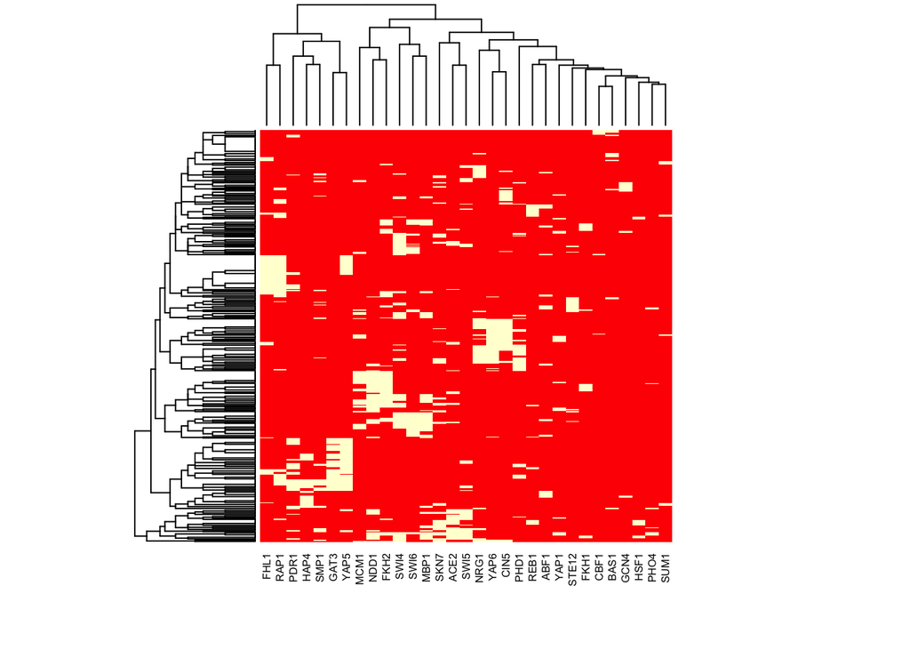

```r
# defined boolean matrix of TF-gene interactions (based on p-value threshold)
B=P<1e-3

Bn=B[rowSums(B)>2, colSums(B)>40] # reduce the problem size
Bn[Bn]=1                          # boolean -> numeric
heatmap(Bn,scale="none",labRow=FALSE, cexCol=0.6)
```

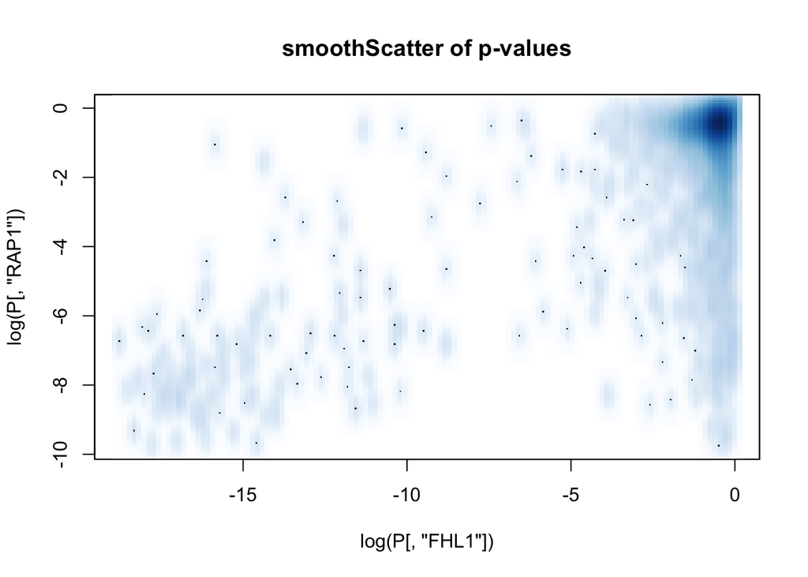

```r
# compare binding p-values for two TF
smoothScatter(log(P[,"FHL1"]),log(P[,"RAP1"]),main="smoothScatter of p-values")
```

```r
table(B[,"FHL1"])               # 194 genes bound by FHL1
```

```
##
## FALSE  TRUE
##  6076   194
```

```r
tb=table(B[,"FHL1"],B[,"RAP1"]) # contingency table: 119 genes bound by FHL1 and RAP1
tb
```

```
##
##         FALSE TRUE
##   FALSE  5989   87
##   TRUE     75  119
```

```r
# Which genes are commonly bound by FHL1 and RAP1?
common_genes=names(which(B[,"FHL1"] & B[,"RAP1"]))

fisher.test(tb)                 # the overlap is highly unexpected
```

```
##
##  Fisher's Exact Test for Count Data
##
## data:  tb
## p-value < 2.2e-16
## alternative hypothesis: true odds ratio is not equal to 1
## 95 percent confidence interval:
##   75.19957 157.98637
## sample estimates:
## odds ratio
##   108.6888
```

```r
chisq.test(tb)
```

```
##
##  Pearson's Chi-squared test with Yates' continuity correction
##
## data:  tb
## X-squared = 2104.6, df = 1, p-value < 2.2e-16
```

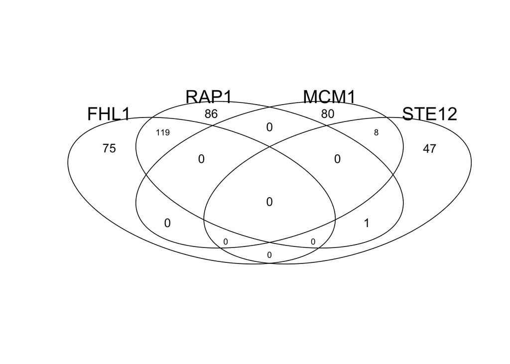

```r
# create a Venn Diagram of target gene overlaps (with package gplots)
library(gplots)
L=list(FHL1=which(B[,"FHL1"]),RAP1=which(B[,"RAP1"]),MCM1=which(B[,"MCM1"]), STE12=which(B[,"STE12"]) )
vn=venn(L)

library(UpSetR)
```

# Review:

- exporting objects as Rdat or text-file
- navigate in directories, know where you are working
- keep data clean and well structured !
- appendix: a (semi-)real-life example
- smoothScatter(), contigency tables, tests, venn (package)